# Summary of exploring a dataset

5 lutego 2018

## Audition task 2018

This is a simple presentation of data from Pearson audition task in 2018. Below I will try to present the information contained in the data.

## Short info about data

The data set comes from a Pearson e-learning platform for English language learners. It’s an online workbook with automatically-graded activities that they used alongside a paper textbook. The activities are either assigned by the teacher as homework or completed voluntarily by learners as extra practice.

- **learner_id:** anonymized learner identifier
- **country:** country code of the learner
- **in_course:** “t” if the learner belongs to course taught by a teacher (as opposed to studying alone)
- **chapter:** number or name of a chapter in the workbook
- **avg_score:** a learner’s avg. percentage score on all activities within a given unit
- **completion:** the percentage of activities completed in a given unit, out of all activities available in that unit
- **inv_rate:** This is the extent to which a learner deviates from the suggested order of activities by the pedagogy experts within a given unit. A value of zero indicates no departure from the suggested order, a value of one indicates a complete reversal of the order.

## How many empty values is in the set

In data set we have 81432 observations.

```
           Empty values
learner_id           17
country              23
in_course             0
unit                 22
avg_score             5
completion            0
inv_rate              5
```

- The data set has empty values, which is not a good property, but unfortunately very real.
- For the rest of the calculations, we will delete rows that do not have a learner ID (as incorrect data, because ID is necessary).
- So now, we have 81415 observations.

## Country (1)

Participants from 88 countries participate in the language course. Below are the 10 most popular countries.

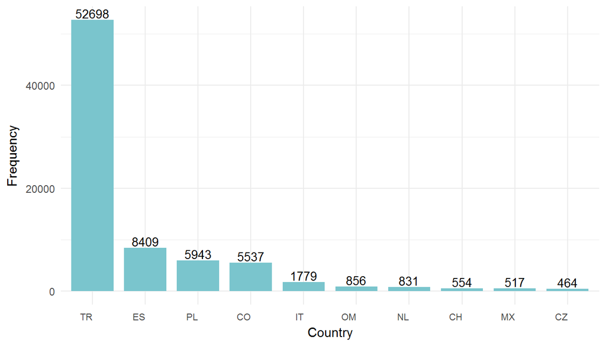

In this graph, we can see that the largest group of students comes from Turkey and Poland occupies 3rd place.

## Country (2)

```
  Country Frequency
1      BD         1
2      PT         1
3      ZW         1
```

Only from Bangladesh, Portugal and Zimbabwe is one participant

## Teacher or self-taught

In the graph below we see, that the vast majority of learners have teacher. Only 7.49% of participants are self-taught. Which could mean that hardly anyone likes to learn on their own.

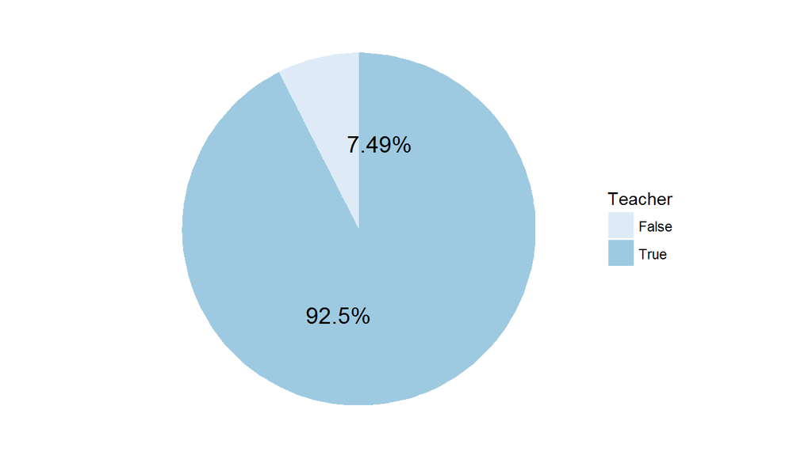

## Progess in unit

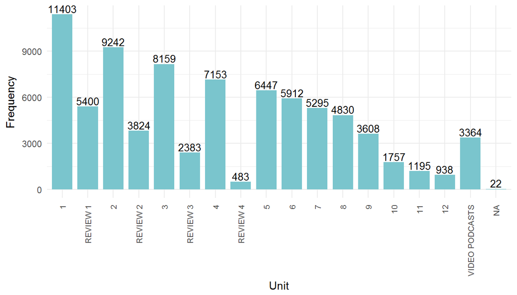

- We can see that most of the learners are at the beginning of the course. We can notice linear trend which is descending.
- Some participants are on video podcast, which can be between each unit.
- And we have some lacks in data, because 22 participants have no assigned a unit.

## Progres in every unit

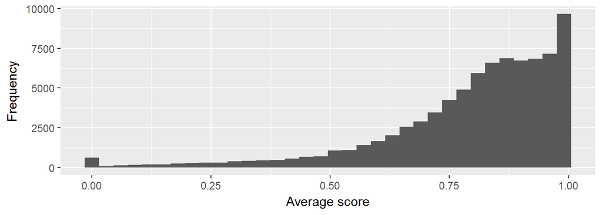

- From the data was removed 3 records, because the percentage was greater than 100%, what is wrong.
- On the graph, we see that most of the learners has done a significant portion of the unit, in which they are.
- Half of the participants achieve at least 83.9% percent of the points in a given unit.
- Less than half of maximum score achieve only 8.09%. So the vast majority of learners won at least half of the points.
- We have small peak on the graph with 0 score. It may mean, that some participants had just signed up for a course or gave up immediately after the start.

## Progres in activities of unit

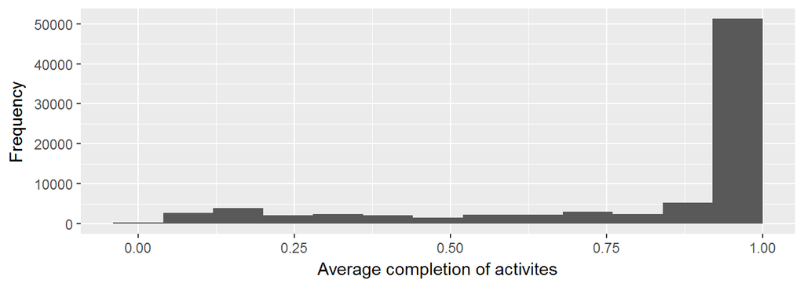

## Achieve score vs done activities

From analyze the data, we see that:

- Not every activities is scored.
- Is easier to make more activities than achieve more score.
- Probably in the course are some activities, which are hard but have more points.
- Easier activities with less points are common
- Participants choose the easier activities than those that are better scored.

## Reversal of the suggested order

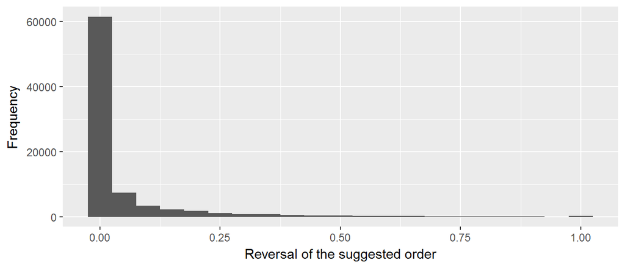

- From the data was removed 3 records, because the percentage was greater than 100%, what is wrong.
- Up to 65.3% of the participants kept to a suggested order.
- Only 1.55% of participants chose the order which is at most 50% of the line with the suggested.
- This could mean that the most of the participants trust the prepared activities sequence or don't try to manually search for the topics that interest them in a given course.